# urban_mobility_economic_analysis

## Introducción

Como analista de datos, tu objetivo es **evaluar cómo la movilidad urbana se relaciona con la productividad económica en las principales ciudades latinoamericanas**. Para ello trabajarás con datos reales de TomTom Traffic Index y OECD Cities, que deberás limpiar, combinar y analizar para identificar en qué ciudades conviene invertir en infraestructura de transporte.

## 🧩 Paso 1: Cargar y explorar

Antes de limpiar o combinar los datos, es necesario **familiarizarte con la estructura de ambos datasets**. En esta etapa, validarás que los archivos se carguen correctamente, conocerás sus columnas y tipos de datos, y detectarás posibles inconsistencias.

### 1.1 Carga de datos y vista rápida

**🎯Objetivo:** Importar las librerías necesarias, cargar los archivos CSV en DataFrames y realizar una revisión preliminar para entender su contenido.

**Instrucciones:**

- Importa las librerías `pandas`, `numpy`, `seaborn` y `matplotlib.pyplot`.
- Carga los archivos usando `pd.read_csv()`:
  - `'/datasets/tomtom_traffic.csv'`
  - `/datasets/oecd_city_economy.csv` `.
- Guarda los DataFrames en las variables `traffic` y `eco`.
- Muestra las primeras 5 filas de cada DataFrame.

```python
# importar librerías
import pandas as pd
import numpy as np
import matplotlib.pyplot as plt
import seaborn as sns
```

```python
# cargar archivos
traffic = pd.read_csv("tomtom_traffic.csv")
economy = pd.read_csv("oecd_city_economy.csv")
```

```python
# mostrar las primeras 5 filas de traffic
traffic.head(5)
```

|  | Country | City | UpdateTimeUTC | JamsDelay | TrafficIndexLive | JamsLengthInKms | JamsCount | TrafficIndexWeekAgo | UpdateTimeUTCWeekAgo | TravelTimeLivePer10KmsMins | TravelTimeHistoricPer10KmsMins | MinsDelay |
| --- | --- | --- | --- | --- | --- | --- | --- | --- | --- | --- | --- | --- |
| 0 | ARE | abu-dhabi | 2025-01-13 04:01:30.001 | 650.7 | 36.0 | 109.1 | 162.0 | 30.0 | 2025-01-06 04:01:30.000 | 11.614767 | 10.265330 | 1.349437 |
| 1 | ARE | abu-dhabi | 2025-01-13 03:46:00.000 | 540.4 | 30.0 | 101.4 | 136.0 | 27.0 | 2025-01-06 03:46:30.001 | 11.003180 | 10.031544 | 0.971635 |
| 2 | ARE | abu-dhabi | 2025-01-13 02:46:30.000 | 71.8 | 7.0 | 18.9 | 23.0 | 6.0 | 2025-01-06 02:46:30.000 | 8.196278 | 8.196510 | -0.000232 |
| 3 | ARE | abu-dhabi | 2025-01-13 01:46:30.001 | 8.2 | 2.0 | 4.1 | 2.0 | 2.0 | 2025-01-06 01:46:30.000 | 7.723808 | 7.899046 | -0.175238 |
| 4 | ARE | abu-dhabi | 2025-01-13 00:01:30.000 | 1.1 | 1.0 | 0.2 | 1.0 | 1.0 | 2025-01-06 00:01:30.000 | 8.336363 | 8.604379 | -0.268016 |

```python
# mostrar las primeras 5 filas de eco
economy.head(5)
```

|  | Year | City | Country | City GDP/capita | Unemployment % | PM2.5 (μg/m³) | Population (M) |
| --- | --- | --- | --- | --- | --- | --- | --- |
| 0 | 2023 | buenos-aires | Argentina | 15.782,00 | 6.2% | 15,2 | 15,30 |
| 1 | 2023 | sao-paulo | Brazil | 14.475,00 | 9.1% | 29,50 | 22,50 |
| 2 | 2023 | rio-de-janeiro | Brazil | 13.142,00 | 9.8% | 19,10 | 13,60 |
| 3 | 2023 | brasilia | Brazil | 15.999,00 | 8.3% | 13,50 | 4,70 |
| 4 | 2023 | salvador | Brazil | 8.761,00 | 13.1% | 16,00 | 3,90 |

## 🧩Paso 2: Explorar, limpiar y preparar los datos

Antes de combinar los datasets, inspecciona su estructura, tipos de datos, columnas y valores faltantes. Anota las columnas que necesiten limpieza y luego estandariza los nombres de columnas.

### 2.1 Explorar la estructura y tipos de datos

**🎯Objetivo:** Identificar columnas con tipos incorrectos, distribución y nulos, anotar las columnas que requieren conversión.

**Instrucciones:**

- Usa `.info()` para conocer la estructura de ambos DataFrames.
- Muestra los primeros 3 renglones de cada DF.
- Identifica si los detalles de cada DF estan bien o si requieren correcciones y escribe tus conclusiones en el bloque Markdown.
  - ¿Hay columnas que requieren conversión?¿ Cuáles son? ¿Que tipo de dato ienen y cuál deberían de tener?
  - ¿Hay datos ausentes en alguna columna?

```python
traffic.info()
```

```
<class 'pandas.core.frame.DataFrame'>
RangeIndex: 1004464 entries, 0 to 1004463
Data columns (total 12 columns):
 #   Column                          Non-Null Count    Dtype
---  ------                          --------------    -----
 0   Country                         1004464 non-null  object
 1   City                            1004464 non-null  object
 2   UpdateTimeUTC                   1004464 non-null  object
 3   JamsDelay                       1004464 non-null  float64
 4   TrafficIndexLive                1004464 non-null  float64
 5   JamsLengthInKms                 1004464 non-null  float64
 6   JamsCount                       1004464 non-null  float64
 7   TrafficIndexWeekAgo             1004464 non-null  float64
 8   UpdateTimeUTCWeekAgo            1004464 non-null  object
 9   TravelTimeLivePer10KmsMins      1004464 non-null  float64
 10  TravelTimeHistoricPer10KmsMins  1004464 non-null  float64
 11  MinsDelay                       1004464 non-null  float64
dtypes: float64(8), object(4)
memory usage: 92.0+ MB
```

```python
economy.info()
```

```
<class 'pandas.core.frame.DataFrame'>
RangeIndex: 30 entries, 0 to 29
Data columns (total 7 columns):
 #   Column           Non-Null Count  Dtype
---  ------           --------------  -----
 0   Year             30 non-null     int64
 1   City             30 non-null     object
 2   Country          30 non-null     object
 3   City GDP/capita  30 non-null     object
 4   Unemployment %   30 non-null     object
 5   PM2.5 (μg/m³)    30 non-null     object
 6   Population (M)   30 non-null     object
dtypes: int64(1), object(6)
memory usage: 1.8+ KB
```

### 2.2 Renombrar columnas

**🎯Objetivo:** Estandarizar los nombres de columnas para evitar errores y facilitar la unión de los datasets.

**Instrucciones:**

- Cambia los nombres de las columnas para que tengan el formato `snake_case`.
  - `Country` → `country`
  - `UpdateTimeUTC` → `update_time_utc`
- Verifica que los cambios se hayan aplicado correctamente usando `.columns`.

```python
# Estandarizar nombres en traffic
traffic = traffic.rename(columns={
    'Country': 'country',
    'City': 'city',
    'UpdateTimeUTC': 'update_time_utc',
    'JamsDelay': 'jams_delay',
    'TrafficIndexLive': 'traffic_index_live',
    'JamsLengthInKms': 'jams_length_kms',
    'JamsCount': 'jams_count',
    'TrafficIndexWeekAgo': 'traffic_index_week_ago',
    'UpdateTimeUTCWeekAgo': 'update_time_utc_week_ago',
    'TravelTimeLivePer10KmsMins': 'travel_time_live_per_10kms_mins',
    'TravelTimeHistoricPer10KmsMins': 'travel_time_historic_per_10kms_mins',
    'MinsDelay': 'mins_delay'
})
traffic.columns
```

```
Index(['country', 'city', 'update_time_utc', 'jams_delay',
       'traffic_index_live', 'jams_length_kms', 'jams_count',
       'traffic_index_week_ago', 'update_time_utc_week_ago',
       'travel_time_live_per_10kms_mins',
       'travel_time_historic_per_10kms_mins', 'mins_delay'],
      dtype='object')
```

```python
traffic = pd.read_csv("tomtom_traffic.csv")
eco = pd.read_csv("oecd_city_economy.csv")

traffic.head()
eco.head()
eco = eco.rename(columns={
    'Year': 'year',
    'City': 'city',
    'Country': 'country',
    'City GDP/capita': 'city_gdp_capita',
    'Unemployment %': 'unemployment_pct',
    'PM2.5 (μg/m³)': 'pm25',
    'Population (M)': 'population_m'
})

eco.columns
```

```
Index(['year', 'city', 'country', 'city_gdp_capita', 'unemployment_pct',
       'pm25', 'population_m'],
      dtype='object')
```

### 2.3 Corregir formatos numéricos y de fecha

**🎯Objetivo:** Asegurar que las columnas de fechas y valores numéricos estén en formatos correctos para permitir análisis, cálculos y comparaciones precisas.

**Instrucciones:**

- Convierte las columnas de fecha de `traffic` a formato `datetime`. Haz el cambio a prueba de errores.
- En el dataset `eco`, limpia los valores numéricos:
  - En `city_gdp_capita`: elimina separadores de miles (`.`) y reemplaza las comas (`','`) por puntos (`'.'`) antes de convertir a tipo `float`.
  - En `unemployment_pct`: elimina el símbolo de porcentaje (`%`) y reemplaza las comas (`','`) por puntos (`'.'`) antes de convertir a tipo `float`.
  - En `population_m`: reemplaza las comas (`','`) por puntos (`'.'`) antes de convertir a tipo `float`.
- Finalmente, crea una nueva columna llamada `population` multiplicando `population_m` por 1,000,000 para obtener la población total.

**Haz clic para ver la pista**

para eliminar símbolos, puedes reemplazarlos por un texto vacío.

```python
traffic['UpdateTimeUTC'] = pd.to_datetime(
    traffic['UpdateTimeUTC'], errors='coerce'
)

traffic['UpdateTimeUTCWeekAgo'] = pd.to_datetime(
    traffic['UpdateTimeUTCWeekAgo'], errors='coerce'
)

traffic.info()
```

```
<class 'pandas.core.frame.DataFrame'>
RangeIndex: 1004464 entries, 0 to 1004463
Data columns (total 12 columns):
 #   Column                          Non-Null Count    Dtype
---  ------                          --------------    -----
 0   Country                         1004464 non-null  object
 1   City                            1004464 non-null  object
 2   UpdateTimeUTC                   1004464 non-null  datetime64[ns]
 3   JamsDelay                       1004464 non-null  float64
 4   TrafficIndexLive                1004464 non-null  float64
 5   JamsLengthInKms                 1004464 non-null  float64
 6   JamsCount                       1004464 non-null  float64
 7   TrafficIndexWeekAgo             1004464 non-null  float64
 8   UpdateTimeUTCWeekAgo            1004464 non-null  datetime64[ns]
 9   TravelTimeLivePer10KmsMins      1004464 non-null  float64
 10  TravelTimeHistoricPer10KmsMins  1004464 non-null  float64
 11  MinsDelay                       1004464 non-null  float64
dtypes: datetime64[ns](2), float64(8), object(2)
memory usage: 92.0+ MB
```

```python
# city_gdp_capita
eco['city_gdp_capita'] = (
    eco['city_gdp_capita']
    .astype(str)
    .str.replace('.', '', regex=False)   # quitar separador de miles
    .str.replace(',', '.', regex=False)  # cambiar coma decimal por punto
    .astype(float)
)

# unemployment_pct
eco['unemployment_pct'] = (
    eco['unemployment_pct']
    .astype(str)
    .str.replace('%', '', regex=False)   # quitar %
    .str.replace(',', '.', regex=False)
    .astype(float)
)

# population_m
eco['population_m'] = (
    eco['population_m']
    .astype(str)
    .str.replace(',', '.', regex=False)
    .astype(float)
)
eco['pm25'] = (
    eco['pm25']
    .astype(str)
    .str.replace(',', '.', regex=False)
    .astype(float)
)

eco['population'] = eco['population_m'] * 1_000_000

eco.info()
eco.head(3)
```

```
<class 'pandas.core.frame.DataFrame'>
RangeIndex: 30 entries, 0 to 29
Data columns (total 8 columns):
 #   Column            Non-Null Count  Dtype
---  ------            --------------  -----
 0   year              30 non-null     int64
 1   city              30 non-null     object
 2   country           30 non-null     object
 3   city_gdp_capita   30 non-null     float64
 4   unemployment_pct  30 non-null     float64
 5   pm25              30 non-null     float64
 6   population_m      30 non-null     float64
 7   population        30 non-null     float64
dtypes: float64(5), int64(1), object(2)
memory usage: 2.0+ KB
```

|  | year | city | country | city_gdp_capita | unemployment_pct | pm25 | population_m | population |
| --- | --- | --- | --- | --- | --- | --- | --- | --- |
| 0 | 2023 | buenos-aires | Argentina | 15782.0 | 6.2 | 15.2 | 15.3 | 15300000.0 |
| 1 | 2023 | sao-paulo | Brazil | 14475.0 | 9.1 | 29.5 | 22.5 | 22500000.0 |
| 2 | 2023 | rio-de-janeiro | Brazil | 13142.0 | 9.8 | 19.1 | 13.6 | 13600000.0 |

## 🧩Paso 3: Extraer año y filtrar

Extraer el año permite filtrar la información y trabajar solo con el período más reciente y relevante.

### 3.1 Extraer columna año y filtrar 2024

**🎯Objetivo** Identificar el año de cada registro y mantener solo los registros del 2024.

**Intrucciones**

- Como el DataFrame `traffic` no tiene una columna de año, utiliza el atributo `.dt.year` sobre su columna de fecha para crear una nueva columna llamada `year`.
- Filtra las filas donde el año sea **2024**.
- Utiliza `.copy()` para crear dos nuevos DataFrames (`traffic_2024` y `eco_2024`) para evitar modificar el dataset original.

```python
traffic.columns = traffic.columns.str.lower()
eco.columns = eco.columns.str.lower()
```

```python
traffic_2024 = traffic.copy()
eco_2024 = eco.copy()

traffic_2024['city'] = traffic_2024['city'].str.lower().str.strip()
eco_2024['city'] = eco_2024['city'].str.lower().str.strip()
eco_2024['country'] = eco_2024['country'].str.lower().str.strip()

display(traffic_2024.head())
display(eco_2024.head())
```

|  | country | city | updatetimeutc | jamsdelay | trafficindexlive | jamslengthinkms | jamscount | trafficindexweekago | updatetimeutcweekago | traveltimeliveper10kmsmins | traveltimehistoricper10kmsmins | minsdelay |
| --- | --- | --- | --- | --- | --- | --- | --- | --- | --- | --- | --- | --- |
| 0 | ARE | abu-dhabi | 2025-01-13 04:01:30.001 | 650.7 | 36.0 | 109.1 | 162.0 | 30.0 | 2025-01-06 04:01:30.000 | 11.614767 | 10.265330 | 1.349437 |
| 1 | ARE | abu-dhabi | 2025-01-13 03:46:00.000 | 540.4 | 30.0 | 101.4 | 136.0 | 27.0 | 2025-01-06 03:46:30.001 | 11.003180 | 10.031544 | 0.971635 |
| 2 | ARE | abu-dhabi | 2025-01-13 02:46:30.000 | 71.8 | 7.0 | 18.9 | 23.0 | 6.0 | 2025-01-06 02:46:30.000 | 8.196278 | 8.196510 | -0.000232 |
| 3 | ARE | abu-dhabi | 2025-01-13 01:46:30.001 | 8.2 | 2.0 | 4.1 | 2.0 | 2.0 | 2025-01-06 01:46:30.000 | 7.723808 | 7.899046 | -0.175238 |
| 4 | ARE | abu-dhabi | 2025-01-13 00:01:30.000 | 1.1 | 1.0 | 0.2 | 1.0 | 1.0 | 2025-01-06 00:01:30.000 | 8.336363 | 8.604379 | -0.268016 |

|  | year | city | country | city_gdp_capita | unemployment_pct | pm25 | population_m | population |
| --- | --- | --- | --- | --- | --- | --- | --- | --- |
| 0 | 2023 | buenos-aires | argentina | 15782.0 | 6.2 | 15.2 | 15.3 | 15300000.0 |
| 1 | 2023 | sao-paulo | brazil | 14475.0 | 9.1 | 29.5 | 22.5 | 22500000.0 |
| 2 | 2023 | rio-de-janeiro | brazil | 13142.0 | 9.8 | 19.1 | 13.6 | 13600000.0 |
| 3 | 2023 | brasilia | brazil | 15999.0 | 8.3 | 13.5 | 4.7 | 4700000.0 |
| 4 | 2023 | salvador | brazil | 8761.0 | 13.1 | 16.0 | 3.9 | 3900000.0 |

## 🧩Paso 4: Analizar y resumir datos de movilidad

Como el dataset de tráfico contiene **múltiples registros por ciudad**. En esta parte, calcularás los promedios anuales por ciudad para simplificar el análisis y obtener una visión más clara de las tendencias generales.

### 4.1 Calcular promedios de tráfico por ciudad

**🎯Objetivo:** Obtener una vista consolidada del tráfico promedio por ciudad y año, para analizar patrones generales sin depender de datos diarios.

**Instrucciones**

- Agrupa los datos por `city`, `country` y `year`.
- Calcula el promedio **solo de las métricas de tráfico más relevantes**: como `jams_delay`, `traffic_index_live`, `jams_length_kms`, `jams_count`, `mins_delay`, y tiempos de viaje (`travel_time_live_per_10kms_mins` y `travel_time_hist_per_10kms_mins`).
- Guarda el resultado como `traffic_city_year_2024`, mantén las columnas como variables (no índices).

**Haz clic para ver la pista**

Usa ".agg()" para aplicar funciones de promedio. Al final, reinicia el índice para mantener las columnas de la agrupación como variables (no índices).

```python
traffic['updatetimeutc'] = pd.to_datetime(traffic['updatetimeutc'])
traffic['year'] = traffic['updatetimeutc'].dt.year
traffic_city_year_2024 = (
    traffic
    .groupby(['city', 'country', 'year'], as_index=False)
    .agg({
        'jamsdelay': 'mean',
        'trafficindexlive': 'mean',
        'jamslengthinkms': 'mean',
        'jamscount': 'mean',
        'minsdelay': 'mean',
        'traveltimeliveper10kmsmins': 'mean',
        'traveltimehistoricper10kmsmins': 'mean'
    })
)

traffic_city_year_2024.head()
```

|  | city | country | year | jamsdelay | trafficindexlive | jamslengthinkms | jamscount | minsdelay | traveltimeliveper10kmsmins | traveltimehistoricper10kmsmins |
| --- | --- | --- | --- | --- | --- | --- | --- | --- | --- | --- |
| 0 | a-coruna | ESP | 2024 | 17.935187 | 15.259774 | 2.198002 | 4.934405 | 0.774172 | 16.267977 | 15.493804 |
| 1 | a-coruna | ESP | 2025 | 11.323684 | 11.055921 | 1.161513 | 3.105263 | 0.402193 | 15.839864 | 15.437671 |
| 2 | aachen | DEU | 2024 | 26.732141 | 20.960314 | 3.892586 | 6.601832 | 0.792968 | 13.397861 | 12.604894 |
| 3 | aachen | DEU | 2025 | 16.278289 | 18.269737 | 3.400000 | 4.144737 | 0.648249 | 13.347184 | 12.698935 |
| 4 | aarhus | DNK | 2024 | 21.200616 | 16.575891 | 2.736736 | 6.109987 | 0.495276 | 15.219292 | 14.724016 |

### 🧠 **Momento de reflexión**

¡Excelente trabajo hasta aquí!

Ahora que ya tienes los promedios anuales por ciudad, es momento de **observarlos** con atención.

Piensa:

- ¿Cuál crees que tiene el mayor tiempo promedio de tráfico?
- ¿Será una ciudad de **Europa**, de **Latinoamérica** o de **otra región** del mundo?

Para descubrirlo, ejecuta esta línea de código:

`traffic_city_year_2024.sort_values(["jams_delay"], ascending=False)`

🔍 Observa qué ciudad aparece en los primeros lugares.

¿Te sorprenden los resultados? , ¿Coinciden con lo que imaginabas?

```python
traffic_city_year_2024.sort_values("jamsdelay", ascending=False).head()
```

|  | city | country | year | jamsdelay | trafficindexlive | jamslengthinkms | jamscount | minsdelay | traveltimeliveper10kmsmins | traveltimehistoricper10kmsmins |
| --- | --- | --- | --- | --- | --- | --- | --- | --- | --- | --- |
| 442 | mexico-city | MEX | 2024 | 2833.057892 | 34.218190 | 389.239265 | 594.969392 | 1.855542 | 21.809092 | 19.953550 |
| 704 | tokyo | JPN | 2024 | 2152.574357 | 36.805059 | 373.069734 | 518.809420 | 0.698152 | 22.443778 | 21.745626 |
| 492 | new-york | USA | 2024 | 2133.400000 | 28.210388 | 398.227892 | 544.474902 | 1.396351 | 18.505043 | 17.108691 |
| 400 | london | GBR | 2024 | 2050.703662 | 29.230166 | 287.632868 | 471.795554 | 1.325160 | 17.714139 | 16.388979 |
| 422 | manila | PHL | 2024 | 1741.493381 | 66.129402 | 246.858082 | 341.881205 | 2.469894 | 27.134629 | 24.664734 |

La ciudad con el mayor tiempo promedio de tráfico es mexico-city — 2833.05

## 🧩Paso 5: Unir movilidad y economía

Combinar datasets te permite analizar cómo se relacionan los indicadores económicos con los de movilidad.

### 5.1 Unir tráfico (tabla principal) con indicadores económicos

**🎯Objetivo:** Combinar la información de tráfico y economía en un solo DataFrame para analizar cómo las condiciones económicas se relacionan con la movilidad urbana.

**Instrucciones**

- Selecciona solo las **columnas relevantes** de cada dataset (por ejemplo, variables clave de tráfico y de economía).
- Usa `.copy()` al crear subconjuntos para evitar modificar el dataset original.
- Une ambos DataFrames y define como **claves de unión** a `city` y `year`.
- Mantén solo las ciudades y años presentes en ambos datasets.
- Guarda el resultado en una nueva variable llamada `merged` y muestra las primeras 5 filas.

**Haz clic para ver la pista**

Aplica una unión de tipo "inner" para mantener las ciudades y años presentes en ambos datasets.

```python
left_cols = [
    'city','country','year','jamsdelay','trafficindexlive',
    'jamslengthinkms','jamscount','minsdelay',
    'traveltimeliveper10kmsmins','traveltimehistoricper10kmsmins'
]

traffic_2024_small = traffic_city_year_2024[left_cols].copy()

right_cols = [
    'city','year','city_gdp_capita',
    'unemployment_pct','pm25','population'
]

eco_2024_small = eco[right_cols].copy()

merged = traffic_2024_small.merge(
    eco_2024_small,
    on=['city','year'],
    how='inner'
)
merged.head()
```

|  | city | country | year | jamsdelay | trafficindexlive | jamslengthinkms | jamscount | minsdelay | traveltimeliveper10kmsmins | traveltimehistoricper10kmsmins | city_gdp_capita | unemployment_pct | pm25 | population |
| --- | --- | --- | --- | --- | --- | --- | --- | --- | --- | --- | --- | --- | --- | --- |
| 0 | belo-horizonte | BRA | 2024 | 263.047879 | 19.428946 | 44.038129 | 68.805422 | 0.487228 | 18.304538 | 17.817311 | 11124.0 | 9.5 | 16.8 | 6100000.0 |
| 1 | bogota | COL | 2024 | 1141.552364 | 37.614273 | 140.893564 | 230.566550 | 1.699628 | 24.992185 | 23.292557 | 11442.0 | 10.0 | 17.6 | 11300000.0 |
| 2 | brasilia | BRA | 2024 | 101.576326 | 11.258220 | 18.337133 | 27.280140 | 0.193442 | 13.338658 | 13.145216 | 16251.0 | 7.8 | 12.8 | 4800000.0 |
| 3 | buenos-aires | ARG | 2024 | 571.089593 | 17.756012 | 100.287844 | 137.359860 | 0.416566 | 17.907916 | 17.491349 | 18117.0 | 7.2 | 14.5 | 15400000.0 |
| 4 | curitiba | BRA | 2024 | 183.469274 | 14.954545 | 30.050044 | 46.898164 | 0.139965 | 17.258700 | 17.118736 | 12381.0 | 8.2 | 13.5 | 3700000.0 |

## 🧩Paso 6: Visualización y análisis de relaciones

Ahora que tienes un dataset limpio y unificado, es momento de **visualizar patrones**. Los gráficos te ayudarán a entender cómo se relacionan las variables económicas con las de movilidad urbana.

### 6.1 Visualizar relaciones entre economía y tráfico

**🎯Objetivo:** Analizar visualmente la distribución y la relación entre indicadores de tráfico y economía en 2024, para identificar posibles patrones o tendencias generales entre ambas variables.

**Instrucciones**

- Usa las librerías `seaborn` y `matplotlib.pyplot` para generar los gráficos.
- Visualiza la distribución del **tráfico** (`jams_delay`) mediante:
  - **Boxplot** → para observar la media, mediana y detectar valores atípicos.
- Visualiza la distribución de la **economía** (`city_gdp_capita`) mediante:
  - **Histograma** → para analizar la forma de la distribución y el valor promedio del PIB per cápita.
- Finalmente, **compara ambas variables**, para observar si existe alguna relación entre ellas, haciendo un solo gráfico de barras donde aparezcan ambos indicadores.
- Recuerda agregar título y etiquetas a los ejes de tus gráficos.
- Observa y comenta los patrones, valores extremos o posibles relaciones que identifiques.

**Tip:** Dentro de los parentesis del boxplot, agrega `showmeans=True` para ver la media en el gráfico.

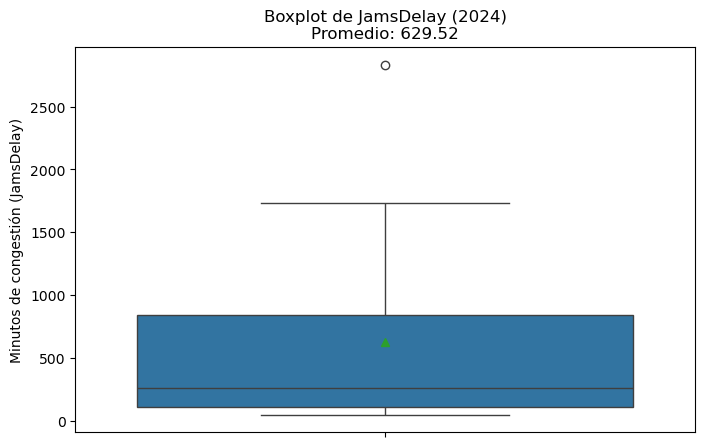

```python
import seaborn as sns
import matplotlib.pyplot as plt

# Crear boxplot
plt.figure(figsize=(8,5))
sns.boxplot(y=merged['jamsdelay'], showmeans=True)

# obtener promedio
mean_value = merged['jamsdelay'].mean()

plt.title(f'Boxplot de JamsDelay (2024)\nPromedio: {mean_value:.2f}')
plt.ylabel('Minutos de congestión (JamsDelay)')
plt.show()
```

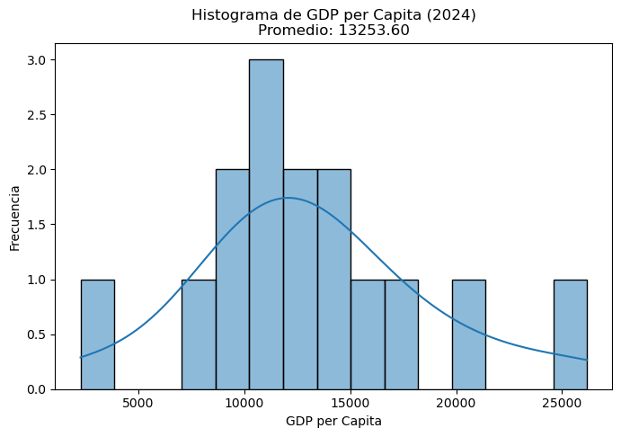

```python
plt.figure(figsize=(8,5))
sns.histplot(merged['city_gdp_capita'], bins=15, kde=True)

mean_gdp = merged['city_gdp_capita'].mean()

plt.title(f'Histograma de GDP per Capita (2024)\nPromedio: {mean_gdp:.2f}')
plt.xlabel('GDP per Capita')
plt.ylabel('Frecuencia')
plt.show()
```

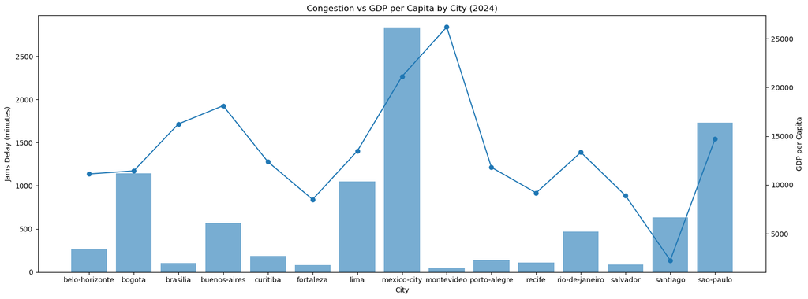

```python
import matplotlib.pyplot as plt

fig, ax1 = plt.subplots(figsize=(16,6))

# Primer eje (izquierda) - congestión
ax1.bar(merged['city'], merged['jamsdelay'], alpha=0.6)
ax1.set_ylabel('Jams Delay (minutes)')
ax1.set_xlabel('City')

# Segundo eje (derecha) - PIB per cápita
ax2 = ax1.twinx()
ax2.plot(merged['city'], merged['city_gdp_capita'], marker='o')
ax2.set_ylabel('GDP per Capita')

plt.title('Congestion vs GDP per Capita by City (2024)')
plt.xticks(rotation=90)
plt.tight_layout()
plt.show()
```

### 🧠 **Reflexiona**

Excelente trabajo llegando a esta etapa del análisis. Antes de avanzar, revisa tus gráficos, tómate un momento para pensar:

- ¿Las ciudades con mayor PIB per cápita también presentan más congestión?
- ¿O sucede lo contrario, o no existe una relación clara?

Escribe tus comentarios: No se observa una relación clara entre el PIB per cápita y la congestión. Algunas ciudades con alto PIB presentan altos niveles de tráfico, mientras que otras no, lo que sugiere que intervienen otros factores en la movilidad urbana.

```python
# Exporta el dataset final como CSV
merged.to_csv("ladb_mobility_economy_2024_clean.csv", index=False)
```

## Resumen Ejecutivo

El objetivo de este análisis fue evaluar si existe una relación entre la movilidad urbana (medida a través de la congestión vehicular y tiempos de retraso) y la productividad económica, representada por el PIB per cápita. Para ello se utilizaron principalmente las variables *jamsdelay* (minutos promedio de retraso por congestión) y *city_gdp_capita*. Estas variables son relevantes porque permiten analizar si un mayor desarrollo económico está asociado con mejores condiciones de movilidad o si el crecimiento viene acompañado de mayores niveles de tráfico.

El análisis se realizó con datos del año 2024, integrando información de distintas ciudades de América Latina. Primero se realizó la limpieza de datos, estandarizando formatos y nombres de columnas. Posteriormente, se agregaron los datos por ciudad–año y se unieron los datasets de tráfico y economía mediante una unión tipo INNER, asegurando que solo se analizaran ciudades con información completa. También se utilizaron visualizaciones como histogramas, boxplots y un gráfico con doble eje para validar distribuciones, detectar posibles outliers y comparar tendencias generales.